# STAT 184 Final Project

Preliminary EDA

Mitchell Wentzel

## Front Matter

```r
# clean up workspace environment
rm(list = ls())
# all packages used for the assignment
library(mosaicData)
library(DataComputing)
library(tidyr)
```

# Preliminary EDA

## Research Question

How does age affect performance in major league sports careers AND do these findings vary across different major sports leagues?

## Information on Data Sources

### Primary Data:

```r
nhl = read.delim("NHLdata.txt", header=TRUE)
summary(nhl)
```

```
                Player         Age              Tm      Pos            GP
 Alex Galchenyuk   :  3   Min.   :18.00   TOT    : 35   C :172   Min.   : 1.0
 Andreas Athanasiou:  3   1st Qu.:23.00   DET    : 22   D :175   1st Qu.:15.0
 Andrew Agozzino   :  3   Median :26.00   OTT    : 21   F :  8   Median :49.0
 Andy Greene       :  3   Mean   :26.35   ANA    : 20   LW: 86   Mean   :41.4
 Barclay Goodrow   :  3   3rd Qu.:29.00   ARI    : 18   RW: 56   3rd Qu.:65.0
 Blake Coleman     :  3   Max.   :42.00   BOS    : 18   W :  2   Max.   :71.0
 (Other)           :481                   (Other):365
       G                A             PTS              X...              PIM
 Min.   : 0.000   Min.   : 0.0   Min.   :  0.00   Min.   :-46.000   Min.   :  0.0
 1st Qu.: 1.000   1st Qu.: 2.0   1st Qu.:  3.00   1st Qu.: -5.000   1st Qu.:  4.5
 Median : 4.000   Median : 7.0   Median : 12.00   Median : -1.000   Median : 14.0
 Mean   : 6.395   Mean   :10.8   Mean   : 17.19   Mean   : -1.271   Mean   : 19.1
 3rd Qu.:10.000   3rd Qu.:17.0   3rd Qu.: 27.50   3rd Qu.:  2.000   3rd Qu.: 28.0
 Max.   :43.000   Max.   :67.0   Max.   :110.00   Max.   : 40.000   Max.   :122.0
```

- Where: Data found at hockey-reference.com, derived from the National Hockey League 2019-2020 Skater Season Statistics data set. I say derived because the original data set had almost 30 variables, so I condensed it to the 10 variables that I saw as most beneficial to my research question.
- Who: The statisticians working for the NHL and the website both collect and maintain the data from year to year, as new statistics are taken.
- Why: This data was originally collected because these same statistics are taken over the course of every NHL season and stored in this website database.
- When: My specific data were taken from the 2019-2020 NHL season.
- What: A case in this data represents an NHL player and their attributes and statistics from the 2019-2020 NHL season.

```r
nhl %>%
  head(5)
```

|  | Player | Age | Tm | Pos | GP | G | A | PTS | X... | PIM |
| --- | --- | --- | --- | --- | --- | --- | --- | --- | --- | --- |
| 1 | Justin Abdelkader | 32 | DET | LW | 49 | 0 | 3 | 3 | -14 | 25 |
| 2 | Pontus Aberg | 26 | TOR | LW | 5 | 0 | 1 | 1 | 0 | 0 |
| 3 | Vitaly Abramov | 21 | OTT | RW | 2 | 1 | 0 | 1 | 0 | 2 |
| 4 | Noel Acciari | 28 | FLA | C | 66 | 20 | 7 | 27 | 2 | 21 |
| 5 | Andrew Agozzino | 29 | TOT | LW | 22 | 1 | 2 | 3 | 3 | 4 |

- Some of the main variables that I plan to use in my research are AGE (Player Age), POS (Player Position), GP (Games Played), PTS (Points Scored), and TM (Team).

```r
names(nhl)
```

```
 [1] "Player" "Age"    "Tm"     "Pos"    "GP"     "G"      "A"      "PTS"    "X..."
[10] "PIM"
```

### Secondary Data:

```r
nfl = read.delim("NFLdata.txt", header=TRUE)
summary(nfl)
```

```
             Player          Tm           Age             Pos            G
 A.J. Brown     :  1   TEN    : 23   Min.   :21.00          :180   Min.   : 1.00
 A.J. Klein     :  1   NWE    : 21   1st Qu.:24.00   WR     : 71   1st Qu.:12.00
 A.J. McCarron  :  1   SFO    : 19   Median :25.00   TE     : 36   Median :15.00
 Aaron Donald*+ :  1   NYG    : 18   Mean   :26.29   RB     : 30   Mean   :13.28
 Aaron Jones    :  1   PHI    : 17   3rd Qu.:28.00   QB     : 26   3rd Qu.:16.00
 Aaron Rodgers *:  1   ATL    : 16   Max.   :47.00   wr     : 15   Max.   :17.00
 (Other)        :464   (Other):356                   (Other):112
      Pts             Pts.G
 Min.   :  2.00   Min.   : 0.10
 1st Qu.:  6.00   1st Qu.: 0.50
 Median : 12.00   Median : 1.10
 Mean   : 24.82   Mean   : 1.96
 3rd Qu.: 33.50   3rd Qu.: 2.60
 Max.   :147.00   Max.   :12.00
```

- Where: Data found at pro-football-reference.com, derived from the National Football League 2019 Season Scoring Leaders Statistics data set. I again say derived because the original data set had about 17 varaiables, so I condensed it to the 7 variables that I saw as most benefical to my research question and most relatable to my primary data set.
- Who: The statisticians working for the NFL and the website both collect and maintain the data from year to year, as new statistics are taken.
- Why: This data was originally collected because these same statistics are taken over the course of every NFL season and stored in this website database.
- When: My specific data were taken from the 2019 NFL season.
- What: A case in this data represents an NFL player and their attributes and scoring statistics from the 2019 NFL season.

```r
nfl %>%
  head(5)
```

|  | Player | Tm | Age | Pos | G | Pts | Pts.G |
| --- | --- | --- | --- | --- | --- | --- | --- |
| 1 | Harrison Butker | KAN | 24 |  | 16 | 147 | 9.2 |
| 2 | Wil Lutz* | NOR | 25 |  | 16 | 144 | 9.0 |
| 3 | Justin Tucker*+ | BAL | 30 |  | 16 | 141 | 8.8 |
| 4 | Zane Gonzalez | ARI | 24 |  | 16 | 127 | 7.9 |
| 5 | Matt Gay | TAM | 25 |  | 16 | 124 | 7.8 |

- Some of the main variables I plan to use in my research are Age (Player Age), Tm (Team), Pos (Player Position), G (Games Played), Pts (Points Scored) and Pts/G (Average Points per game).

```r
names(nfl)
```

```
[1] "Player" "Tm"     "Age"    "Pos"    "G"      "Pts"    "Pts.G"
```

### Explore Intuition

- Relationship between Age and Points Scored in NHL data.

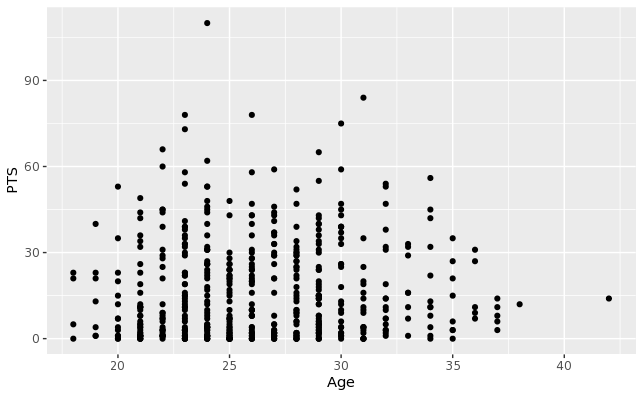

```r
nhl %>%
  ggplot(aes(x=Age, y=PTS)) +
  geom_point()
```

- Relationship between Age and Points Scored in NFL data.

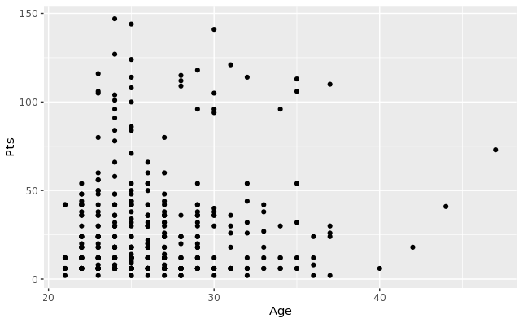

```r
nfl %>%
  ggplot(aes(x=Age, y=Pts)) +
  geom_point()
```

- Relationship between Age and Points Scored in NHL data, by Positions.

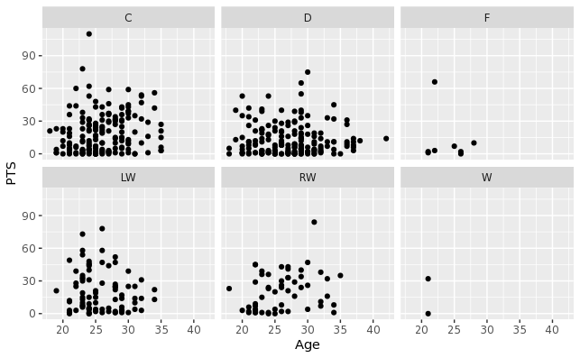

```r
nhl %>%
  ggplot(aes(x=Age, y=PTS)) +
  geom_point() +
  facet_wrap(~Pos, ncol = 3)
```

- Relationship between Age and Points Scored in NFL data, by a few positions.

```
longer object length is not a multiple of shorter object lengthlonger object length is not a multiple of shorter object length
```

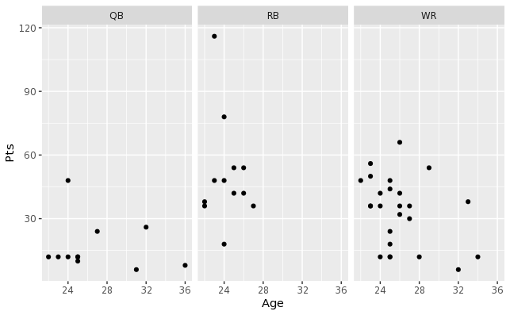

```r
nfl %>%
  filter(Pos == c("QB", "RB", "WR")) %>%
  ggplot(aes(x=Age, y=Pts)) +
  geom_point() +
  facet_wrap(~Pos, ncol = 3)
```

- Relationship between Age and Games Played in NHL.

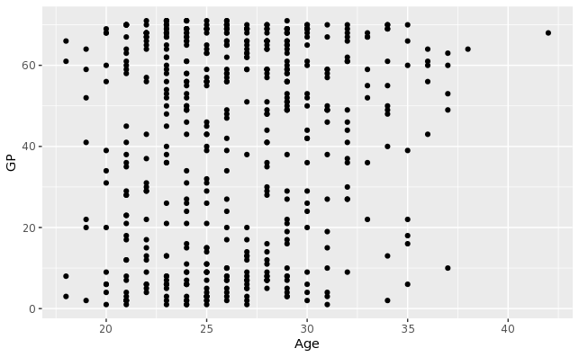

```r
nhl %>%
  ggplot(aes(x=Age, y=GP)) +
  geom_point()
```

- Relationship between Age and Games Played in NFL.

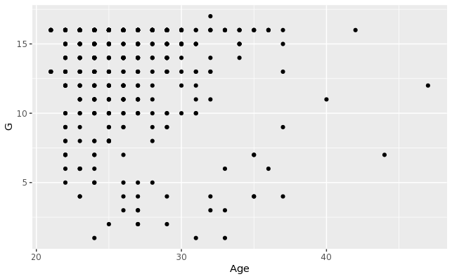

```r
nfl %>%
  ggplot(aes(x=Age, y=G)) +
  geom_point()
```

Above, I have created 6 basic informative plots that could help me in the start of my research.

Overall, the observations from these 6 plots are very informative about some preliminary information related to my research question. This is a very good start to analyzing the data further, and diving deeper into my research question.

### Two Data Sources

- NHL 2019-2020 Data

```r
xfun::embed_file('NHLdata.txt')
```

Download NHLdata.txt

- NFL 2019 Data

```r
xfun::embed_file('NFLdata.txt')
```

Download NFLdata.txt

### References

- https://www.hockey-reference.com/
- https://www.pro-football-reference.com/